# individual2.Rmd

Mike Brown

4/13/2021

```r
library(tidyverse)
```

```r
library(dplyr)
library(ggplot2)
library(lubridate)
library(tidyr)
library(classdata)
library(plotly)
library(ggrepel)
acc <- read.csv("C:/Users/brown/OneDrive/Desktop/DS202/Lab 5/ds202_lab5/accident.csv", stringsAsFactors = FALSE)
per <- read.csv("C:/Users/brown/OneDrive/Desktop/DS202/Lab 5/ds202_lab5/person.csv", stringsAsFactors = FALSE)
```

1.Are there some days of the week where more accidents happen than the others (see FARS manual, use variable `DAY_WEEK`)?

Answer:

```r
acc1 <- wday(acc$DAY_WEEK, label = TRUE)
as.data.frame(table(acc1))
```

```
##   acc1 Freq
## 1  Sun 5360
## 2  Mon 4374
## 3  Tue 4347
## 4  Wed 4314
## 5  Thu 4621
## 6  Fri 5358
## 7  Sat 5873
```

Saturday has more accidents than any other day of the week.

2.Create a data frame containing the persons who are fatally hurt in the accidents (look up variable `INJ_SEV`).

Answer:

```r
fatal <- filter(per, INJ_SEV == 4)
head(fatal)
```

```
##   STATE ST_CASE VE_FORMS VEH_NO PER_NO STR_VEH COUNTY DAY MONTH HOUR MINUTE
## 1     1   10001        1      1      1       0     73  19     2   23     35
## 2     1   10002        1      1      1       0     89  14     2   14     59
## 3     1   10003        3      2      1       0    101  31     1   20     31
## 4     1   10004        1      1      1       0     73   1     1   16     55
## 5     1   10005        1      1      1       0     13   1     1   20      0
## 6     1   10006        2      1      1       0     49   6     1   18     40
##   RUR_URB FUNC_SYS HARM_EV MAN_COLL SCH_BUS MAKE MAK_MOD BODY_TYP MOD_YEAR
## 1       2        1      38        0       0   20   20421       15     2004
## 2       2        1       1        0       0   37   37402       14     2005
## 3       2        1      12        1       0    2    2404       14     2003
## 4       2        4      30        0       0   30   30046        4     2014
## 5       1        1      35        0       0   12   12471       34     2010
## 6       1        1      34        0       0   49   49032        4     1997
##   TOW_VEH SPEC_USE EMER_USE ROLLOVER IMPACT1 FIRE_EXP AGE SEX PER_TYP INJ_SEV
```

[output cut: 41 more lines]

3.Create a data frame containing the most dangerous vechitle make in each state. The number of persons fatally hit in the vehicle make is used to assess the (non-)safety of a make. Make sure to handle the missing values appropriately. (look up variable `MAKE`)

```r
GLC <- readxl::read_xlsx("C:/Users/brown/OneDrive/Desktop/DS202/Lab 5/ds202_lab5/FRPP_GLC_-_United_StATESaPRIL62021.xlsx")
```

```r
perMDV <- fatal %>% select(STATE, MAKE, INJ_SEV) %>% na.omit() %>% group_by(STATE, MAKE) %>% summarise(count = n())
perMDVRes <- perMDV %>% group_by(STATE) %>% top_n(1, count)
accLongLatAVG <- acc %>%
  group_by(STATE) %>%
  summarise(avgLong = mean(LONGITUD), avgLat = mean(LATITUDE))

perMDVResLatLong <- full_join(perMDVRes, accLongLatAVG, by = "STATE")
```

5.Join the accident and person table (work out which varaible(s) to use)

Answer:

```r
join <-left_join(per, acc, by="ST_CASE")
head(join)
```

```
##   STATE.x ST_CASE VE_FORMS.x VEH_NO PER_NO STR_VEH COUNTY.x DAY.x MONTH.x
## 1       1   10001          1      1      1       0       73    19       2
## 2       1   10002          1      1      1       0       89    14       2
## 3       1   10003          3      1      1       0      101    31       1
## 4       1   10003          3      2      1       0      101    31       1
## 5       1   10003          3      3      1       0      101    31       1
## 6       1   10004          1      1      1       0       73     1       1
##   HOUR.x MINUTE.x RUR_URB.x FUNC_SYS.x HARM_EV.x MAN_COLL.x SCH_BUS.x MAKE
## 1     23       35         2          1        38          0         0   20
## 2     14       59         2          1         1          0         0   37
## 3     20       31         2          1        12          1         0   82
## 4     20       31         2          1        12          1         0    2
## 5     20       31         2          1        12          1         0   84
## 6     16       55         2          4        30          0         0   30
##   MAK_MOD BODY_TYP MOD_YEAR TOW_VEH SPEC_USE EMER_USE ROLLOVER IMPACT1 FIRE_EXP
```

[output cut: 83 more lines]

6.Tally the number of accidents by day of the week (Day_WEEK), hour of the day (HOUR) and gender (SEX). Visualize the results and explain what you find.

Answer:

```r
join$DAY_WEEK <- wday(join$DAY_WEEK, label=TRUE)
tally2<-join %>% group_by(DAY_WEEK, HOUR.x, SEX) %>% summarize(count=n())
tally<- summarize(group_by(join,DAY_WEEK, HOUR.x, SEX),count=n())
```

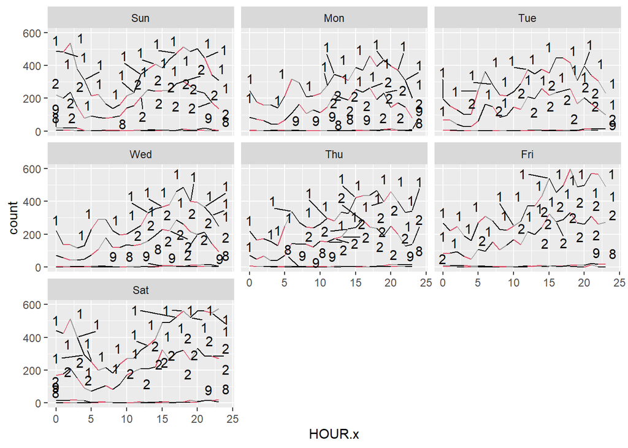

```r
ggplot(tally2, aes(x=HOUR.x, y=count, group=SEX))+geom_line(color=tally$SEX)+geom_text_repel(aes(x=HOUR.x,y=count,label=SEX))+facet_wrap(~DAY_WEEK)+xlim(0,24)
```

This faceted graph shows that males are more likely to be in an accident no matter what the time is. This also shows that crashes are more frequent on the weekends closer to the end of the day. This is likely due to people partying on their days off and attempting to drive home when they’re done.

7.Now plot a choropleth map of the number of deaths on a county level. Also explain what you find.

8. Is summer or winter more dangerous? Does this depend on states? Explore and explain.